# PSYCH 260/BBH 203

2022-03-29 08:20:58

[video not shown]

2:25

## Announcements

- Quiz 3 today, after class until 10 pm
- Exam 3 next Thursday, March 31

## Today’s Topics

- Wrap up on [schizophrenia](https://psu-psychology.github.io/psych-260-2022-spring/lectures/260-2022-03-17-schizophrenia.html#29)
- Biology of emotion
- Happiness/pleasure and reward
- Fear & stress

## Biology of Emotion

- What is emotion?
- What are the types of emotions?
- Biological systems involved in emotion

## What is emotion?

- Feelings
- Physiological state

## Emotions as actions

https://www.biomotionlab.ca/html5-bml-walker/

## What is cause? What is effect?

> “Do we run from a bear because we are afraid or are we afraid because we run? William James posed this question more than a century ago, yet the notion that afferent visceral signals are essential for the unique experiences of distinct emotions remains a key unresolved question at the heart of emotional neuroscience.”

[(Harrison, Gray, Gianaros, & Critchley, 2010)](http://doi.org/10.1523/JNEUROSCI.1725-10.2010)

## Competing views

- James-Lange
  - Physiological response -> subjective feelings
- Cannon-Bard
  - Severing CNS (spinal cord & vagus, Xth n) from rest of body leaves emotional expression unchanged
  - Physiological states slow, don’t differentiate among emotions

## Competing views

- Schacter-Singer
  - Physiological arousal + cognitive appraisal -> emotional states

## What are the different types of emotions?

[figure not shown]

(Plutchik, 1980)

## Emotions

- Vary in valence
  - Positive/negative
- Vary in intensity (arousal)
- Vary in action tendency
  - Approach/avoid

## Emotions (can) serve biological goals

- Ingestion
- Defense
- Reproduction
- Affiliation

[figure not shown]

(Plutchik, 1980)

## Is emotion distinct from cognition?

[figure not shown]

[(Pessoa, 2008)](http://dx.doi.org/10.1038/nrn2317)

## [(Pessoa, 2008)](http://dx.doi.org/10.1038/nrn2317)

*Here, I will argue that complex cognitive–emotional behaviours have their basis in dynamic coalitions of networks of brain areas, none of which should be conceptualized as specifically affective or cognitive. Central to cognitive–emotional interactions are brain areas with a high degree of connectivity, called hubs, which are critical for regulating the flow and integration of information between regions.*

## [(Pessoa, 2008)](http://dx.doi.org/10.1038/nrn2317)

*Here, I will argue that complex cognitive–emotional behaviours have their basis in dynamic coalitions of networks of brain areas, none of which should be conceptualized as specifically affective or cognitive. Central to cognitive–emotional interactions are brain areas with a high degree of connectivity, called hubs, which are critical for regulating the flow and integration of information between regions.*

## Emotion as “computing” (or information processing)

- Input
  - Internal states
  - External world
- Processing/evaluation
- Output
  - Internal states
  - External world

## *Where* in the brain is emotion processed?

[figure not shown]

[(Lindquist, Wager, Kober, Bliss-Moreau, & Barrett, 2012)](http://dx.doi.org/10.1017/S0140525X11000446)

## Locationist account

> Figure 1. Locationist Hypotheses of Brain–Emotion Correspondence. A: Lateral view. B: Sagital view at the midline. C: Ventral view. D: Coronal view. Brain regions hypothesized to be associated with emotion categories are depicted. Here we depict the most popular locationist hypotheses, although other locationist hypotheses of brain–emotion correspondence exist (e.g., Panksepp, Reference Panksepp 1998). Fear: amygdala (yellow); Disgust: insula (green); Anger: OFC (rust); Sadness: ACC (blue). A color version of this image can be viewed in the online version of this target article at http://www.journals.cambridge.org/bbs.

> [(Lindquist et al., 2012)](http://dx.doi.org/10.1017/S0140525X11000446)

## Constructionist account

> A psychological constructionist account of emotion assumes that emotions are psychological events that emerge out of more basic psychological operations that are not specific to emotion. In this view, mental categories such as anger, sadness, fear, et cetera, are not respected by the brain (nor are emotion, perception, or cognition, for that matter).

> [(Lindquist et al., 2012)](http://dx.doi.org/10.1017/S0140525X11000446)

> …emotions emerge when people make meaning out of sensory input from the body and from the world using knowledge of prior experiences. Emotions are “situated conceptualizations” (cf. Barsalou 2003) because the emerging meaning is tailored to the immediate environment and prepares the person to respond to sensory input in a way that is tailored to the situation,

> [(Lindquist et al., 2012)](http://dx.doi.org/10.1017/S0140525X11000446)

## Happiness and reward

## Components of happiness

- [Aristotle](http://plato.stanford.edu/entries/aristotle-ethics/)
- Hedonia
  - Pleasure
- Eudaimonia
  - Life satisfaction
  - Relates to motivation

## “Computing” pleasure

- Inputs
  - External
  - Internal
- Processing
- Outputs
  - Feelings
  - Actions

## Brain mechanisms

- Circuits for signaling pleasure and pain
- Similarities across animal species
  - Behavior & brain
- Dopamine and endogenous opioid neurotransmitter systems involved

## Neuroanatomy of pleasure

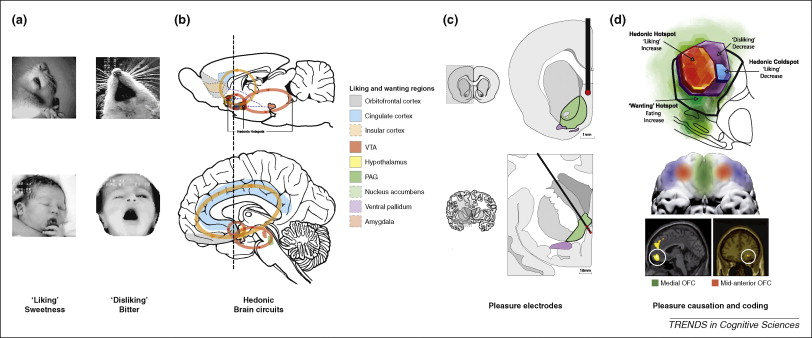

[(Kringelbach & Berridge, 2009)](http://dx.doi.org/10.1016/j.tics.2009.08.006)

## Rewards

- A *reward* reinforces (makes more prevalent/probable) some behavior
- Milner and Olds (Milner, 1989) discovered ‘rewarding’ power of electrical self-stimulation
- [(Heath, 1963)](http://doi.org/10.1176/ajp.120.6.571) studied effects in human patients.

## Electrical self-stimulation

[video not shown]

## “Reward” circuitry in the brain

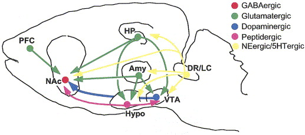

[(Nestler & Carlezon, 2006)](http://dx.doi.org/10.1016/j.biopsych.2005.09.018)

## Nodes in the “reward” circuit

- Ventral tegmental area (VTA) in midbrain
- Nucleus accumbens (nAcc), ventral striatum
- Hypothalamus (Hyp)
- Amygdala (Amy)
- Hippocampus (HP)
- Dorsal Raphe Nucleus/Locus Coeruleus (DR/LC)
- Prefrontal cortex (PFC)

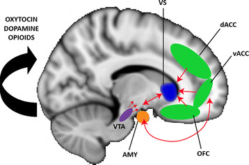

[(Kohls, Chevallier, Troiani, & Schultz, 2012)](http://dx.doi.org/10.1186/1866-1955-4-10)

## Psychopharmacology of ‘happiness’

- Dopamine
- Serotonin, Norepinephrine
- ACh

## ACh projections in the CNS

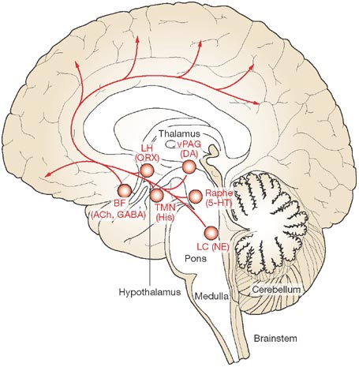

[(Cock, Vidailhet, & Arnulf, 2008)](http://dx.doi.org/10.1038/ncpneuro0775)

## Brain contains its own systems for binding drugs associated with ‘pleasure’

- Endorphins: Endogenous morphine-like compounds
  - e.g., morphine, heroin, oxycontin (oxycodone) are opioids

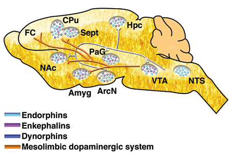

[(Clapp, Bhave, & Hoffman, n.d.)](http://pubs.niaaa.nih.gov/publications/arh314/310-339.htm)

## Comparative risk

> “*A comparative risk assessment of drugs including alcohol and tobacco using the margin of exposure (MOE) approach was conducted. The MOE is defined as ratio between toxicological threshold (benchmark dose) and estimated human intake. Median lethal dose values from animal experiments were used to derive the benchmark dose. The human intake was calculated for individual scenarios and population-based scenarios…*”

> [(Lachenmeier & Rehm, 2015)](http://dx.doi.org/10.1038/srep08126%22)

> “*…For individual exposure the four substances alcohol, nicotine, cocaine and heroin fall into the “high risk” category with MOE < 10, the rest of the compounds except THC fall into the “risk” category with MOE < 100.*”

> [(Lachenmeier & Rehm, 2015)](http://dx.doi.org/10.1038/srep08126%22)

## Brain contains its own systems for binding drugs associated with ‘pleasure’

- Endogenous cannabinoids
  - Cannabinoids == psychoactive compounds found in cannibis
  - Cannabinoid receptors: CB1 in CNS; CB2 in body, immune system

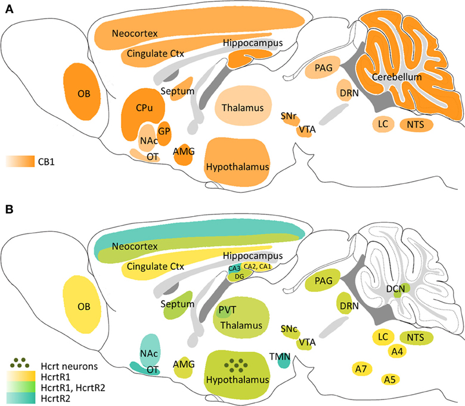

[(Flores, Maldonado, & Berrendero, 2013)](http://dx.doi.org/10.3389/fnins.2013.00256)

## Generalizations about happiness/pleasure

- Types of pleasure activate overlapping areas
- Pleasure/happiness engage a network of brain areas
- Pleasure/happiness signaling involves multiple neuromodulators, but DA especially important
- “Reward” pathways activated by many different inputs
- Some exogenous substances bind to endogenous receptor systems

## References

Clapp, P., Bhave, S. V., & Hoffman, P. L. (n.d.). How Adaptation of the Brain to Alcohol Leads to Dependence. Retrieved from http://pubs.niaaa.nih.gov/publications/arh314/310-339.htm

Cock, V. C. D., Vidailhet, M., & Arnulf, I. (2008). Sleep disturbances in patients with parkinsonism. *Nature Clinical Practice Neurology*, *4*(5), 254–266. https://doi.org/10.1038/ncpneuro0775

Harrison, N. A., Gray, M. A., Gianaros, P. J., & Critchley, H. D. (2010). The embodiment of emotional feelings in the brain. *J. Neurosci.*, *30*(38), 12878–12884. https://doi.org/10.1523/JNEUROSCI.1725-10.2010

Heath, R. G. (1963). Electrical self-stimulation of the brain in man. *American Journal of Psychiatry*, *120*(6), 571–577. https://doi.org/10.1176/ajp.120.6.571

Kohls, G., Chevallier, C., Troiani, V., & Schultz, R. T. (2012). Social ‘wanting’dysfunction in autism: Neurobiological underpinnings and treatment implications. *Journal of Neurodevelopmental Disorders*, *4*(10), 1–20. https://doi.org/10.1186/1866-1955-4-10

Kringelbach, M. L., & Berridge, K. C. (2009). Towards a functional neuroanatomy of pleasure and happiness. *Trends in Cognitive Sciences*, *13*(11), 479–487.

Lachenmeier, D. W., & Rehm, J. (2015). Comparative risk assessment of alcohol, tobacco, cannabis and other illicit drugs using the margin of exposure approach. *Scientific Reports*, *5*, 8126. https://doi.org/10.1038/srep08126

Lindquist, K. A., Wager, T. D., Kober, H., Bliss-Moreau, E., & Barrett, L. F. (2012). The brain basis of emotion: A meta-analytic review. *The Behavioral and Brain Sciences*, *35*(3), 121–143. https://doi.org/10.1017/S0140525X11000446

Milner, P. M. (1989). The discovery of self-stimulation and other stories. *Neuroscience & Biobehavioral Reviews*, *13*(2–3), 61–67. https://doi.org/10.1016/S0149-7634(89)80013-2

Nestler, E. J., & Carlezon, W. A. (2006). The mesolimbic dopamine reward circuit in depression. *Biological Psychiatry*, *59*(12), 1151–1159. https://doi.org/10.1016/j.biopsych.2005.09.018

Pessoa, L. (2008). On the relationship between emotion and cognition. *Nature Reviews Neuroscience*, *9*(2), 148–158. https://doi.org/10.1038/nrn2317

Plutchik, R. (1980). *Emotion: A psychoevolutionary synthesis*. Harpercollins College Division.